# 14_resize_image_even_border

## 14_resize_image_even_border

#### Question

1. The inner dimensions of a frame are 36 inches by 15 inches. An artist hopes to print an image with an aspect ratio of 3.26 such that a uniformly wide mat fits around the image.

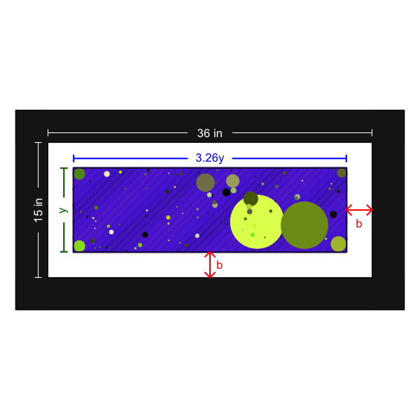

   Find $b$, the width of the mat in inches. The tolerance is $\pm 0.01$ inches.

#### Question

2. The inner dimensions of a frame are 26 inches by 12 inches. An artist hopes to print an image with an aspect ratio of 2.95 such that a uniformly wide mat fits around the image.

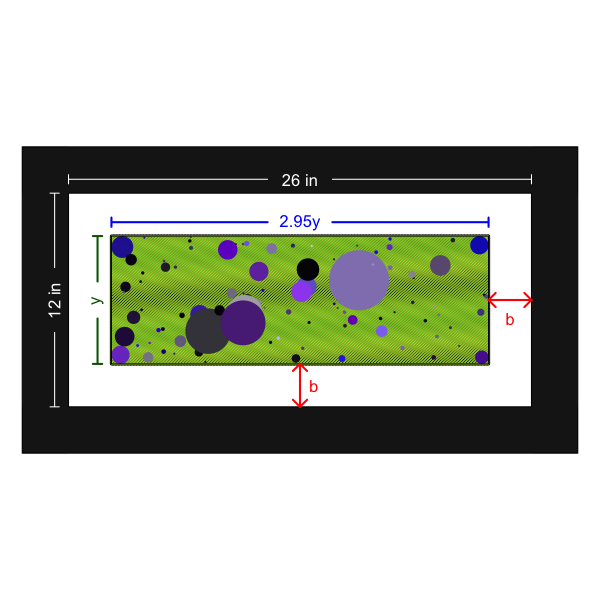

   Find $y$, the height of the image in inches. The tolerance is $\pm 0.01$ inches.

#### Question

3. The inner dimensions of a frame are 32 inches by 22 inches. An artist hopes to print an image with an aspect ratio of 1.86 such that a uniformly wide mat fits around the image.

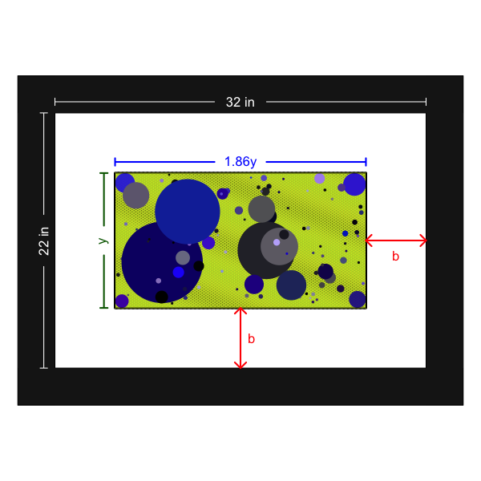

   Find $b$, the width of the mat in inches. The tolerance is $\pm 0.01$ inches.

#### Question

4. The inner dimensions of a frame are 35 inches by 17 inches. An artist hopes to print an image with an aspect ratio of 2.47 such that a uniformly wide mat fits around the image.

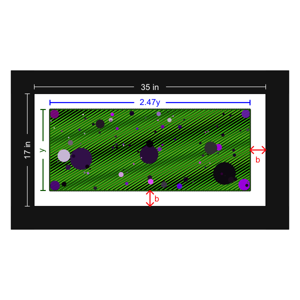

   Find $b$, the width of the mat in inches. The tolerance is $\pm 0.01$ inches.

#### Question

5. The inner dimensions of a frame are 28 inches by 20 inches. An artist hopes to print an image with an aspect ratio of 1.67 such that a uniformly wide mat fits around the image.

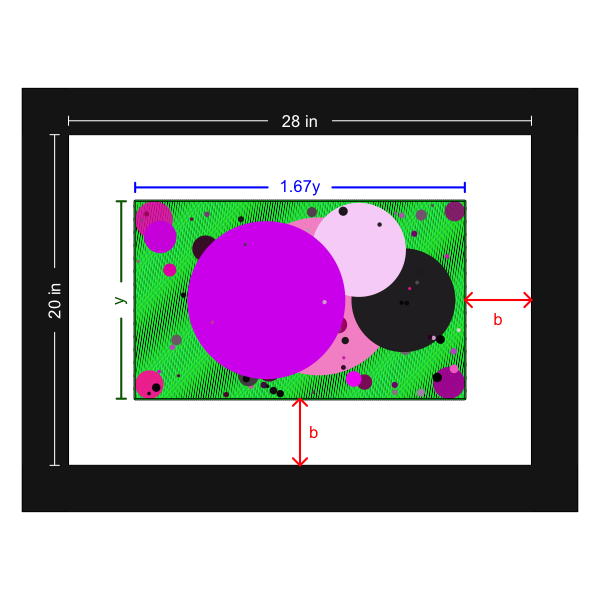

   Find $b$, the width of the mat in inches. The tolerance is $\pm 0.01$ inches.

#### Question

6. The inner dimensions of a frame are 24 inches by 12 inches. An artist hopes to print an image with an aspect ratio of 2.33 such that a uniformly wide mat fits around the image.

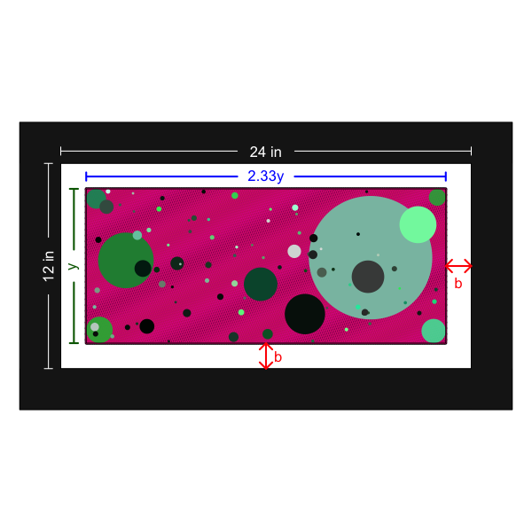

   Find $y$, the height of the image in inches. The tolerance is $\pm 0.01$ inches.

#### Question

7. The inner dimensions of a frame are 37 inches by 17 inches. An artist hopes to print an image with an aspect ratio of 2.87 such that a uniformly wide mat fits around the image.

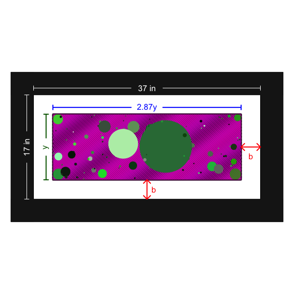

   Find $y$, the height of the image in inches. The tolerance is $\pm 0.01$ inches.

#### Question

8. The inner dimensions of a frame are 29 inches by 16 inches. An artist hopes to print an image with an aspect ratio of 2.36 such that a uniformly wide mat fits around the image.

[figure not shown]

   Find $b$, the width of the mat in inches. The tolerance is $\pm 0.01$ inches.